#NORMALITY TESTS IN ECONOMETRICS USING R  
##Author: R J Neel  
###Referene: Ben Lambert Econometrics Course, Introductory Econometrics: A modern approach by J Wooldrige, Econometric Analysis by W. Greene

Let us consider an example from the **wage1** dataset. Here, we test the relationship between wage and education and experience.

```
##   wage educ exper tenure nonwhite female married numdep smsa northcen south
## 1 3.10   11     2      0        0      1       0      2    1        0     0
## 2 3.24   12    22      2        0      1       1      3    1        0     0
## 3 3.00   11     2      0        0      0       0      2    0        0     0
## 4 6.00    8    44     28        0      0       1      0    1        0     0
## 5 5.30   12     7      2        0      0       1      1    0        0     0
## 6 8.75   16     9      8        0      0       1      0    1        0     0
##   west construc ndurman trcommpu trade services profserv profocc clerocc
## 1    1        0       0        0     0        0        0       0       0
## 2    1        0       0        0     0        1        0       0       0
## 3    1        0       0        0     1        0        0       0       0
## 4    1        0       0        0     0        0        0       0       1
## 5    1        0       0        0     0        0        0       0       0
## 6    1        0       0        0     0        0        1       1       0
##   servocc    lwage expersq tenursq
## 1       0 1.131402       4       0
## 2       1 1.175573     484       4
## 3       0 1.098612       4       0
## 4       0 1.791759    1936     784
## 5       0 1.667707      49       4
## 6       0 2.169054      81      64
```

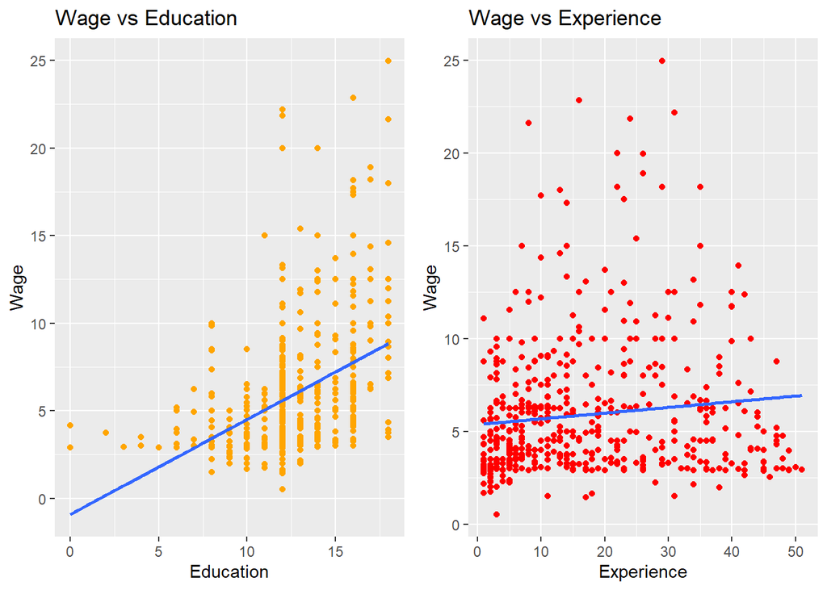

We devise the following model:  
wage=f(education, experience)

Therefore, we devise the following model:  
$Wage=\beta_0 + \beta_1*Education +\beta_2*Experience$

The result of regression is

```
##
## Call:
## lm(formula = wage ~ educ + exper, data = data)
##
## Coefficients:
## (Intercept)         educ        exper
##     -3.3905       0.6443       0.0701
```

```
##
## Call:
## lm(formula = wage ~ educ + exper, data = data)
##
## Residuals:
##     Min      1Q  Median      3Q     Max
## -5.5532 -1.9801 -0.7071  1.2030 15.8370
##
## Coefficients:
##             Estimate Std. Error t value Pr(>|t|)
## (Intercept) -3.39054    0.76657  -4.423 1.18e-05 ***
## educ         0.64427    0.05381  11.974  < 2e-16 ***
## exper        0.07010    0.01098   6.385 3.78e-10 ***
## ---
## Signif. codes:  0 '***' 0.001 '**' 0.01 '*' 0.05 '.' 0.1 ' ' 1
##
## Residual standard error: 3.257 on 523 degrees of freedom
## Multiple R-squared:  0.2252, Adjusted R-squared:  0.2222
## F-statistic: 75.99 on 2 and 523 DF,  p-value: < 2.2e-16
```

```
## Analysis of Variance Table
##
## Response: wage
##            Df Sum Sq Mean Sq F value    Pr(>F)
## educ        1 1179.7 1179.73 111.208 < 2.2e-16 ***
## exper       1  432.5  432.52  40.772  3.78e-10 ***
## Residuals 523 5548.2   10.61
## ---
## Signif. codes:  0 '***' 0.001 '**' 0.01 '*' 0.05 '.' 0.1 ' ' 1
```

Thus, we have $Wage=-3.39+0.64*Education +0.07*Experience$

Now, we test for **NORMALITY**

Let us see the distribution of wages

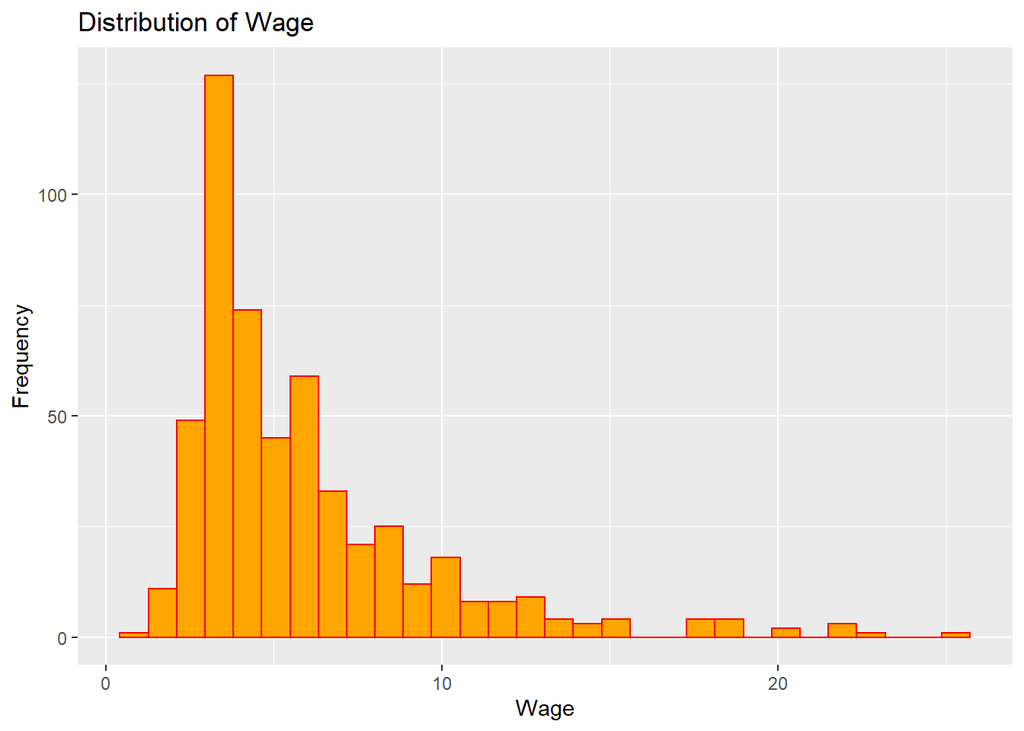

Prima facie it looks like the distribution is **skewed** towards the right.

Let us conduct all the normality tests

**[1]Visual Tests**

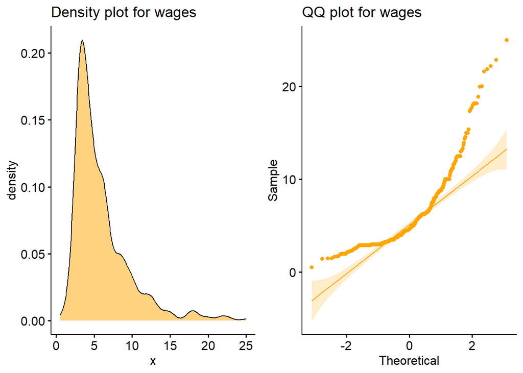

**[2]Jarque-Berra Test**

```
##
##  Jarque Bera Test
##
## data:  data$wage
## X-squared = 894.62, df = 2, p-value < 2.2e-16
```

**INTERPRETATION**  
For Jarque-Berra test our  
*Ho: Distribution is NORMAL*  
*Ha: Otherwise*  
A p value of $<0.05$ implies That the test stastic lies in the REJECTION REGION. Therefore, We **fail** to conclude that the distribution is **NORMAL**. It was already hinted in the Visual tests.

**[3]Shapiro-Wilk Test**

```
##
##  Shapiro-Wilk normality test
##
## data:  data$wage
## W = 0.80273, p-value < 2.2e-16
```

As is in the case for Jarque-Berra test, In Shapiro-Wilkins test too = our  
*Ho: Distribution is NORMAL*  
*Ha: Otherwise*  
A p value of $<0.05$ implies That the test stastic lies in the REJECTION REGION. Therefore, We **fail** to conclude that the distribution is **NORMAL**. It was already hinted in the Visual tests.

Shapiro-wilk is the more preferred test.

**Let us now repeat the exercise with Log(wages)**  
Let us see the distribution of Log(wages)

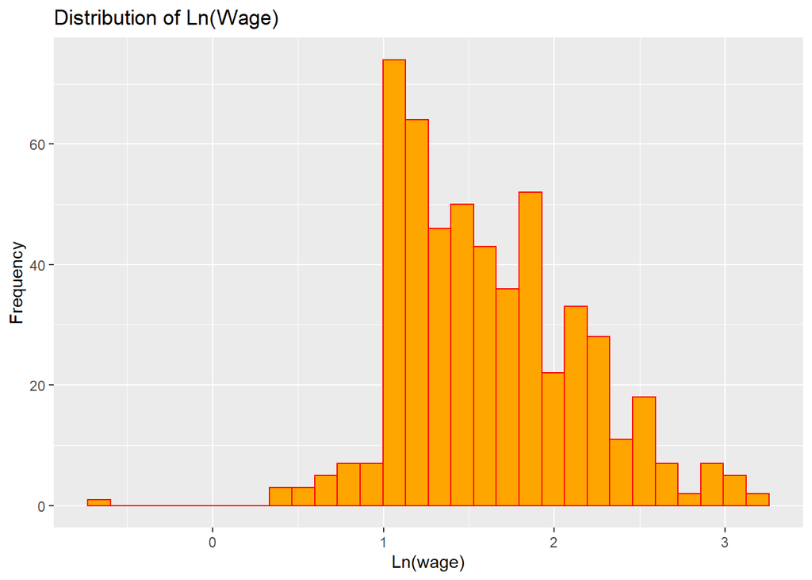

Prima facie it does **NOT** look **NORMAL**

Let us conduct all the normality tests

**[1]Visual Tests**

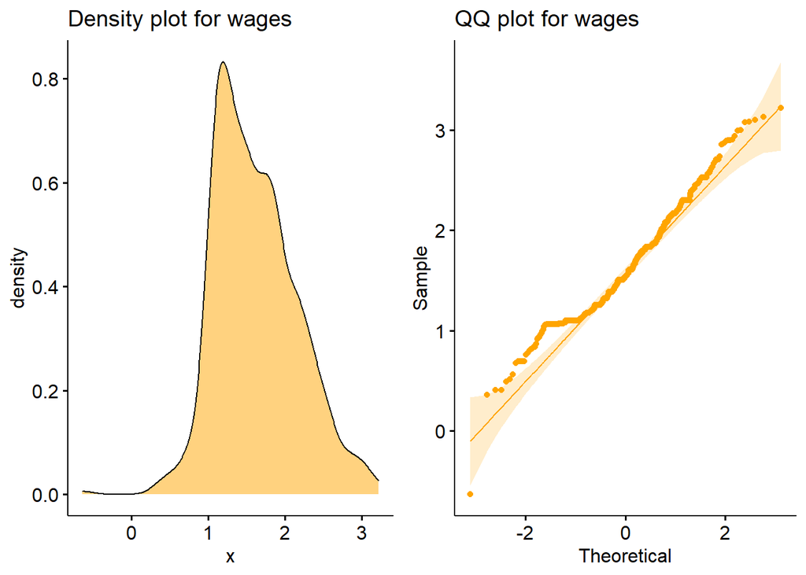

**[2]Jarque-Berra Test**

```
##
##  Jarque Bera Test
##
## data:  log(data$wage)
## X-squared = 16.67, df = 2, p-value = 0.0002399
```

**INTERPRETATION**  
The p value has increased but it is still $<0.05$ implies That the test stastic lies in the REJECTION REGION. Therefore, We **fail** to conclude that the distribution is **NORMAL**. It was already hinted in the Visual tests.

**[3]Shapiro-Wilk Test**

```
##
##  Shapiro-Wilk normality test
##
## data:  log(data$wage)
## W = 0.96909, p-value = 4.423e-09
```

As is in the case for Jarque-Berra test, In Shapiro-Wilkins test too it fails to prove **NORMALITY**